# Data analysis

Larkin, Beck, & Bajer

2020-02-19

### Load libraries

```r
library(vegan)
library(GGally)
library(mvabund)
library(dplyr)
library(mosaic)
library(ggplot2)
library(stringr)
library(Hmisc)
library(onewaytests)
library(FD)
library(tibble)
library(sjPlot)
library(ggeffects)
library(grid)
library(gridExtra)
options(width=160)
```

# Data prep

Read in and organize data

- “speciesTraits” = Native/non-native status, perennial/annual, growth form, and C-value for 206 taxa

```r
speciesTraits <- read.csv("speciesTraits.csv")
```

- “allData_913” = environmental, carp, and macrophyte data for all 913 lakes

```r
allData_913 <- read.csv("allData_913.csv")
```

- “commData_913” = macrophyte community data only (pres/abs) for all 913 lakes (206 taxa)

```r
commData_913 <- allData_913
cols.keep <- which(colnames(commData_913) == "acorus_calamus_var._americanus"):dim(commData_913)[2]
commData_913 <- commData_913[,cols.keep]
cols.drop <- which(colSums(commData_913) == 0)
commData_913 <- commData_913[,-cols.drop]
dim(commData_913)
```

```
## [1] 913 206
```

Standardizing environmental predictor variables to mean 0, SD 1

```r
stdVar <- function(x){(x - mean(x)) / sd(x)}

allData_913$std.log.depth <- stdVar(log(allData_913$depthm + 1))
allData_913$std.log.carp <- stdVar(log(allData_913$cpue.carp + 1))
allData_913$std.phuman <- stdVar(allData_913$phuman)
allData_913$std.invSecchi <- stdVar(allData_913$invSecchi)
allData_913$std.sdi <- stdVar(allData_913$sdi)
allData_913$std.log.area <- stdVar(log(allData_913$aream2))
```

Reducing dataset by dropping rare taxa (occurring in <2.5% of lakes). This reduces dataset to 119 taxa, and 906 lakes w/ >=2 of the retained taxa

- “allData_906” = environmental, carp, and macrophyte data for 906 lakes
- “commData_906” = macrophyte community data for 906 lakes

```r
commData_906 <- commData_913
numbRecs <- apply(commData_906, c(2), length)
lengthNotZero.fun <- function(x) length(which(x!=0))
numbNotZero <- apply(commData_906, c(2), lengthNotZero.fun)
sppFreq <- numbNotZero/numbRecs
commData_906 <- commData_906[, sppFreq >= 0.025]
drop.rows <- which(rowSums(commData_906) < 2)
commData_906 <- commData_906[-drop.rows,]
allData_906 <- allData_913
allData_906 <- allData_913[-drop.rows,]
dim(commData_906)
```

```
## [1] 906 119
```

# NMDS ordination

```r
set.seed(17)
commData_906.nms <- metaMDS(commData_906, k = 3, distance = "bray")
```

```r
commData_906.nms
```

```
##
## Call:
## metaMDS(comm = commData_906, distance = "bray", k = 3)
##
## global Multidimensional Scaling using monoMDS
##
## Data:     commData_906
## Distance: bray
##
## Dimensions: 3
## Stress:     0.1603807
## Stress type 1, weak ties
## No convergent solutions - best solution after 20 tries
## Scaling: centring, PC rotation, halfchange scaling
## Species: expanded scores based on 'commData_906'
```

## Figure 1

See R file for code

# Multivariate GLM

Predictor variables

- Ecoregion = ‘ecoregion’
- Sampling year = ‘fish.year’
- Sampling season = ‘season’
- Lake area = ‘aream2’ (ln transformed)
- Maximum depth = ‘depthm’ (ln transformed)
- Inverse Secchi depth = ‘invSecchi’
- Proportion anthropogenic land use = ‘phuman’
- Lake morphometry (shoreline development index) = ‘SDI’
- Carp CPUE = ‘cpue.carp’ (ln(x+1) transformed)

Checking for excess collinearity between predictor variables

All pairwise correlations <= 0.52. Reasonable to retain all predictors

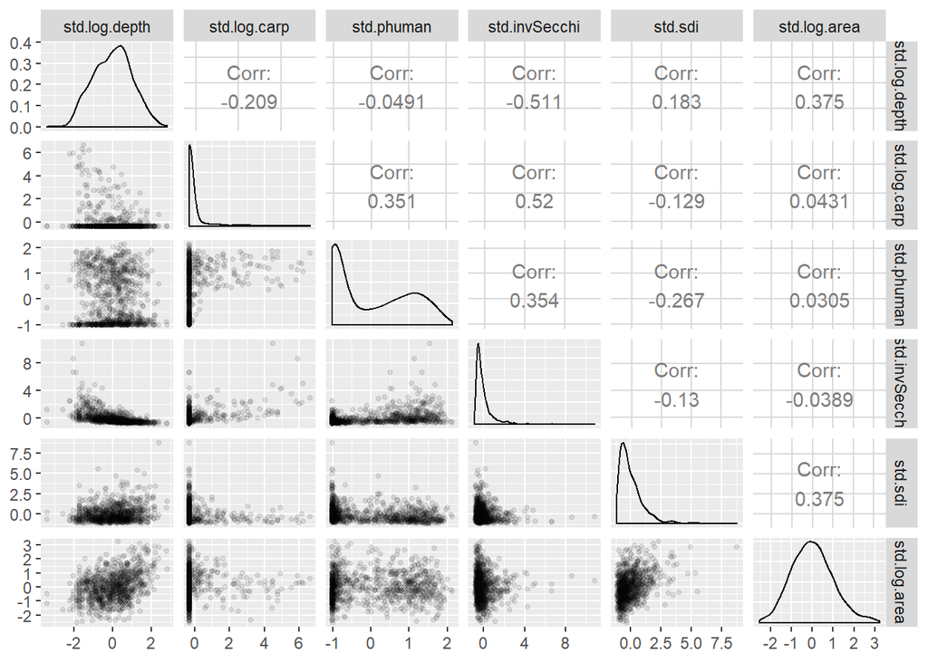

```r
ggpairs(allData_906[, c(238:243)], lower = list(continuous = wrap("points", alpha = 0.1, size = 1)))
```

## All ecoregions

Fitting full multivariate glm w/ interactions

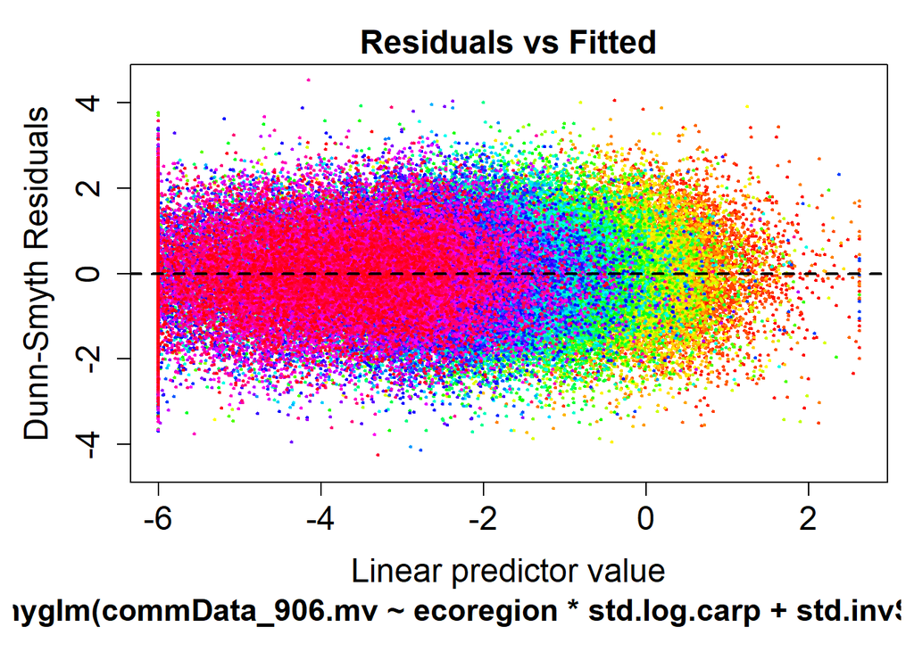

```r
commData_906.mv <- mvabund(commData_906)
commData_906.glm.full <- manyglm(commData_906.mv ~ ecoregion*std.log.carp + std.invSecchi*std.log.carp
                            + std.log.area + std.log.depth + fish.year + std.phuman + std.sdi
                            + season, data = allData_906, family=binomial("cloglog"))
plot(commData_906.glm.full, overlay = TRUE, cex = 0.1, pch = 1)
```

Analysis of deviance for mv glm

```r
nboot <- 1000
commData_906.glm.full.adev <- anova.manyglm(commData_906.glm.full, nBoot=nboot)
```

```
## Time elapsed: 5 hr 31 min 16 sec
```

```r
commData_906.glm.full.adev
```

```
## Analysis of Deviance Table
##
## Model: manyglm(formula = commData_906.mv ~ ecoregion * std.log.carp +
## Model:     std.invSecchi * std.log.carp + std.log.area + std.log.depth +
## Model:     fish.year + std.phuman + std.sdi + season, family = binomial("cloglog"),
## Model:     data = allData_906)
##
## Multivariate test:
##                            Res.Df Df.diff  Dev Pr(>Dev)
## (Intercept)                   905
## ecoregion                     903       2 6877    0.001 ***
## std.log.carp                  902       1  626    0.001 ***
## std.invSecchi                 901       1 1221    0.001 ***
## std.log.area                  900       1 1552    0.001 ***
## std.log.depth                 899       1  339    0.001 ***
## fish.year                     898       1 4401    0.001 ***
## std.phuman                    897       1  779    0.001 ***
## std.sdi                       896       1  562    0.001 ***
## season                        894       2  318    0.005 **
## ecoregion:std.log.carp        892       2  217    0.078 .
## std.log.carp:std.invSecchi    891       1  167    0.002 **
## ---
## Signif. codes:  0 '***' 0.001 '**' 0.01 '*' 0.05 '.' 0.1 ' ' 1
## Arguments:
##  Test statistics calculated assuming uncorrelated response (for faster computation)
##  P-value calculated using 1000 resampling iterations via PIT-trap resampling (to account for correlation in testing).
```

Reducing model (backwards selection)

Dropping non-significant ecoregion x carp interaction

```r
commData_906.glm <- manyglm(commData_906.mv ~ ecoregion + std.log.carp + std.invSecchi*std.log.carp
                            + std.log.area + std.log.depth + fish.year + std.phuman + std.sdi
                            + season, data = allData_906, family=binomial("cloglog"))
commData_906.glm.adev <- anova.manyglm(commData_906.glm, nBoot=nboot)
```

```
## Time elapsed: 4 hr 45 min 50 sec
```

```r
commData_906.glm.adev
```

```
## Analysis of Deviance Table
##
## Model: manyglm(formula = commData_906.mv ~ ecoregion + std.log.carp +
## Model:     std.invSecchi * std.log.carp + std.log.area + std.log.depth +
## Model:     fish.year + std.phuman + std.sdi + season, family = binomial("cloglog"),
## Model:     data = allData_906)
##
## Multivariate test:
##                            Res.Df Df.diff  Dev Pr(>Dev)
## (Intercept)                   905
## ecoregion                     903       2 6877    0.001 ***
## std.log.carp                  902       1  626    0.001 ***
## std.invSecchi                 901       1 1221    0.001 ***
## std.log.area                  900       1 1552    0.001 ***
## std.log.depth                 899       1  339    0.001 ***
## fish.year                     898       1 4401    0.001 ***
## std.phuman                    897       1  779    0.001 ***
## std.sdi                       896       1  562    0.001 ***
## season                        894       2  318    0.005 **
## std.log.carp:std.invSecchi    893       1  181    0.004 **
## ---
## Signif. codes:  0 '***' 0.001 '**' 0.01 '*' 0.05 '.' 0.1 ' ' 1
## Arguments:
##  Test statistics calculated assuming uncorrelated response (for faster computation)
##  P-value calculated using 1000 resampling iterations via PIT-trap resampling (to account for correlation in testing).
```

## Excluding northern forests

Dropping lakes from Northern Forests ecoregion where carp rare

```r
# Proportion of NF lakes w/ carp
sum(as.numeric(allData_913$cpue.carp[allData_913$ecoregion == "northern forests"] > 0)) /
  length(allData_913$cpue.carp[allData_913$ecoregion == "northern forests"])
```

```
## [1] 0.01247401
```

```r
drop.rows <- which(allData_913$ecoregion == "northern forests")
allData_NoNF <- allData_913[-drop.rows,]
commData_NoNF <- commData_913[-drop.rows,]
```

Removing species found in <2.5% of lakes, and then lakes w/ <2 species

```r
numbRecs <- apply(commData_NoNF, c(2), length)
numbNotZero <- apply(commData_NoNF, c(2), lengthNotZero.fun)
sppFreq <- numbNotZero/numbRecs
commData_NoNF <- commData_NoNF[, sppFreq >= 0.025]
drop.rows <- which(rowSums(commData_NoNF) < 2)
commData_NoNF <- commData_NoNF[-drop.rows,]
allData_NoNF <- allData_NoNF[-drop.rows,]
```

Numbers of lakes and taxa

```r
dim(commData_NoNF)
```

```
## [1] 426  92
```

Fitting multivariate glm

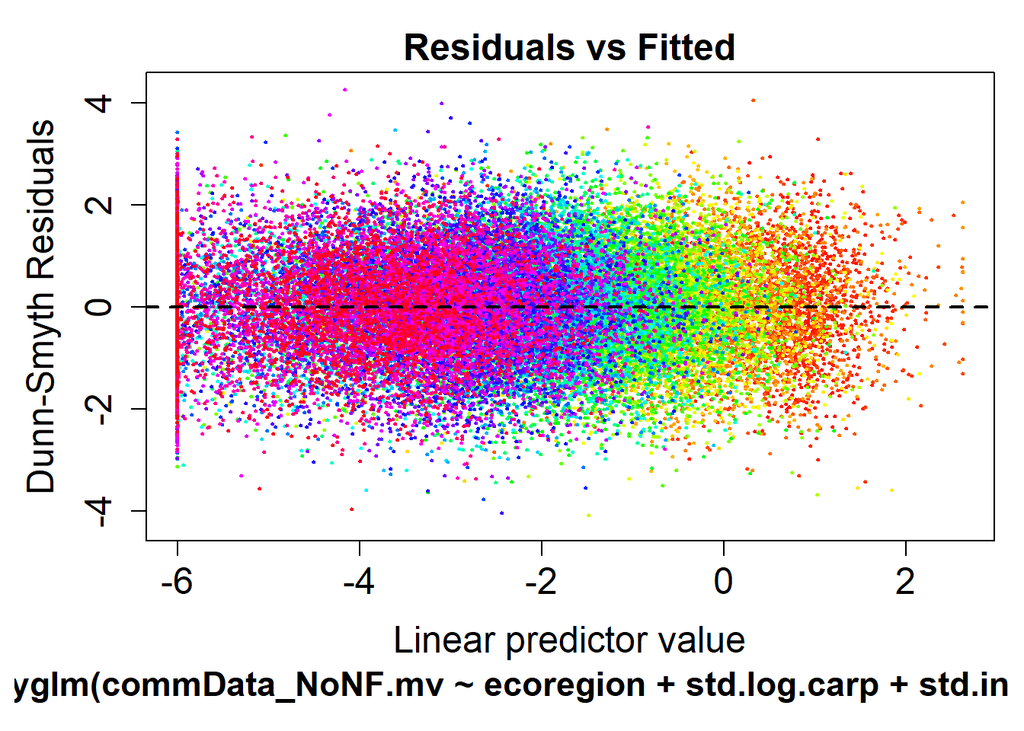

```r
commData_NoNF.mv <- mvabund(commData_NoNF)
commData_NoNF.glm <- manyglm(commData_NoNF.mv ~  ecoregion + std.log.carp + std.invSecchi*std.log.carp
                             + std.log.area + std.log.depth + fish.year + std.phuman + std.sdi + season,
                             data = allData_NoNF, family=binomial("cloglog"))
plot(commData_NoNF.glm, overlay = TRUE, cex = 0.1, pch = 1)
```

Analysis of deviance for mv glm

```r
commData_NoNF.glm.adev <- anova.manyglm(commData_NoNF.glm, nBoot=nboot)
```

```
## Time elapsed: 1 hr 46 min 14 sec
```

```r
commData_NoNF.glm.adev
```

[output not shown]

# Individual species responses

Excluding species w/ few records (<25) outside NF ecoregion (and thus minimal potential overlap w/ carp)

```r
ecoregCounts <- aggregate(. ~ allData_906$ecoregion, commData_906, sum)
northernSpp <- names(which(colSums(ecoregCounts[-3,-1]) < 25))
commData_906.uni <- commData_906[ , !names(commData_906) %in% northernSpp]
```

Function for univariate GLM

```r
glm.fun <- function(x){
  glm(x ~ ecoregion + std.invSecchi*std.log.carp + std.log.area
      + std.log.depth + fish.year + std.phuman + std.sdi + season, data = allData_906,
      family=binomial("cloglog"))
}
```

Function to randomize carp CPUE data across lakes to generate expectations under null model of no carp effect

```r
glm.shuffle <- function(x){
  glm(x ~ ecoregion + std.invSecchi*shuffle(std.log.carp) + std.log.area
      + std.log.depth + fish.year + std.phuman + std.sdi + season, data = allData_906,
      family=binomial("cloglog"))
}
```

## Example species

```r
j <- "myriophyllum_sibiricum"
test.glm <- glm.fun(commData_906.uni[,j])
```

Observed carp coefficient

```r
test.stat <- c(coef(test.glm)["std.log.carp"],
               coef(test.glm)["std.invSecchi:std.log.carp"]); test.stat
```

```
##               std.log.carp std.invSecchi:std.log.carp
##                 -0.6778623                  0.1697463
```

Distribution of expected carp coefficients under null hypothesis of no carp effect

```r
onesided <- matrix(NA, nboot, 2)
for(i in 1:nboot){
  mod1 <- glm.shuffle(commData_906.uni[,j])
  onesided[i,] <- c(coef(mod1)["shuffle(std.log.carp)"],
                    coef(mod1)["std.invSecchi:shuffle(std.log.carp)"])
}
```

One-sided test of probability that observed carp coefficient < null expectation

Carp main effect

```r
sum(onesided[,1] <= test.stat[1])/nboot
```

```
## [1] 0
```

Carp x turbidity interaction

```r
sum(onesided[,2] <= test.stat[2])/nboot
```

```
## [1] 0.975
```

## All species

Observed carp coefficients for all species

```r
species <- c(1:dim(commData_906.uni)[2])
carp.coef <- data.frame()
for(j in species){
  glm.j <- glm.fun(commData_906.uni[,j])
  carp.coef.j <- data.frame(row.names = names(commData_906.uni)[j],
                            carp.coef = summary(glm.j)$coefficients["std.log.carp","Estimate"],
                            carp.se = summary(glm.j)$coefficients["std.log.carp","Std. Error"],
                            carp.turb.coef = summary(glm.j)$coefficients["std.invSecchi:std.log.carp","Estimate"],
                            carp.turb.se = summary(glm.j)$coefficients["std.invSecchi:std.log.carp","Std. Error"])
  carp.coef <- rbind(carp.coef, carp.coef.j)
}
```

Loop to generate null expectations for each species

```r
set.seed(23)
carp.null <- vector(length(species), mode = "list")
names(carp.null) <- names(commData_906.uni)[species]
for(j in species){
  onesided <- matrix(NA, nboot, 2)
  for(i in 1:nboot){
    glm.shuffle.j <- glm.shuffle(commData_906.uni[,j])
    onesided[i,] <- cbind(coef(glm.shuffle.j)["shuffle(std.log.carp)"],
                          coef(glm.shuffle.j)["std.invSecchi:shuffle(std.log.carp)"])
  }
  carp.null[[j]] <- data.frame(onesided)
  names(carp.null[[j]]) <- c("carp.main", "carp.interaction")
}
```

Calculating p-value for each species

```r
carp.coef.p <- carp.coef
carp.coef.p <- transform(carp.coef.p, carp.p = 0, carp.turb.p = 0)
for(j in species){
  carp.coef.p[j,5] <- sum(unlist(carp.null[[j]][,"carp.main"]) <= carp.coef[j,"carp.coef"])/nboot
  carp.coef.p[j,6] <- sum(unlist(carp.null[[j]][,"carp.interaction"]) <= carp.coef[j,"carp.turb.coef"])/nboot
}
head(carp.coef.p)
```

```
##                             carp.coef    carp.se carp.turb.coef carp.turb.se carp.p carp.turb.p
## asclepias_incarnata       -0.03416915 0.11885368   -0.006179801   0.03360315  0.420       0.478
## bidens_beckii             -3.18737758 1.63759779   -4.933617912   3.87602447  0.000       0.000
## bolboschoenus_fluviatilis  0.40688316 0.09171951   -0.112899465   0.03263801  0.812       0.297
## carex_sp                  -0.20319854 0.10863909    0.027385315   0.03134998  0.001       0.693
## ceratophyllum_demersum    -0.16463072 0.07734871   -0.007262715   0.02745183  0.005       0.469
## chara_sp                  -0.44364650 0.11243977    0.184482201   0.04299339  0.000       0.972
```

## Carp effect vs. turbidity effect

Loop for inverse Secchi coefficients for all species

```r
species <- c(1:dim(commData_906.uni)[2])
turb.coef <- data.frame()
for(j in species){
  glm.j <- glm.fun(commData_906.uni[,j])
  turb.coef.j <- data.frame(row.names = names(commData_906.uni)[j],
                            turb.coef = summary(glm.j)$coefficients["std.invSecchi","Estimate"],
                            turb.se = summary(glm.j)$coefficients["std.invSecchi","Std. Error"])
  turb.coef <- rbind(turb.coef, turb.coef.j)
}
head(turb.coef)
```

```
##                             turb.coef    turb.se
## asclepias_incarnata        0.15018301 0.12632028
## bidens_beckii             -1.94076492 1.21283688
## bolboschoenus_fluviatilis  0.40183219 0.11344739
## carex_sp                  -0.01686020 0.09266282
## ceratophyllum_demersum    -0.02563348 0.08380533
## chara_sp                  -1.01076732 0.13516946
```

Paired t-test

```r
t.test(carp.coef$carp.coef, turb.coef$turb.coef, paired = T)
```

```
##
##  Paired t-test
##
## data:  carp.coef$carp.coef and turb.coef$turb.coef
## t = -0.64903, df = 69, p-value = 0.5185
## alternative hypothesis: true difference in means is not equal to 0
## 95 percent confidence interval:
##  -0.268408  0.136633
## sample estimates:
## mean of the differences
##              -0.0658875
```

# Species characteristics

Ordering by significance and magnitude of carp effects

```r
carpResponse <- carp.coef.p[order(carp.coef.p$carp.p, carp.coef.p$carp.coef),]
sig <- ifelse(carpResponse$carp.coef < 0 & carpResponse$carp.p <= 0.05 |
                carpResponse$carp.coef < 0 & carpResponse$carp.turb.p <= 0.05,
              1, 0)
carpResponse <- transform(carpResponse, sig = sig, Carp_response = 0)
```

Taxa w/ sig. negative carp coefficients “sensitive”, else “neutral”

```r
carpResponse$Carp_response[carpResponse$sig == 1] <- "sensitive"
carpResponse$Carp_response[carpResponse$Carp_response==0] <- "neutral"
carpResponse$Species <- rownames(carpResponse)
```

Joining w/ species trait data

```r
responseTraits <- left_join(carpResponse, speciesTraits)
responseTraits %>%
  group_by(Carp_response) %>%
  summarise(n=n())
```

```
## # A tibble: 2 x 2
##   Carp_response     n
##   <chr>         <int>
## 1 neutral          41
## 2 sensitive        29
```

## Figure 2

See R file for code

## Ecoregion prediction data

Ecoregional mean environmental covariates and carp values (0/mean/max)

Northern Forests

```r
nForests <- droplevels(subset(allData_913, ecoregion == "northern forests"))
nForests.newdata <- data.frame(ecoregion = "northern forests",
                               std.log.area = mean(nForests$std.log.area),
                               std.log.depth = mean(nForests$std.log.depth),
                               std.sdi = mean(nForests$std.sdi),
                               fish.year = mean(nForests$fish.year),
                               std.invSecchi = mean(nForests$std.invSecchi),
                               std.phuman = mean(nForests$std.phuman),
                               std.log.carp = mean(nForests$std.log.carp),
                               season = "mid_sum")
nForests.newdata <- nForests.newdata[rep(seq_len(nrow(nForests.newdata[1])), each=3),]
nForests.newdata$std.log.carp[1] <- min(nForests$std.log.carp)
nForests.newdata$std.log.carp[3] <- max(nForests$std.log.carp)
```

Eastern Temperate Forests (same as above, see R file for code)

Great Plains (same as above, see R file for code)

Untransformed carp CPUE mean and max. values

```r
gPlains.carp <- droplevels(subset(allData_913, ecoregion == "great plains"))
c(mean(gPlains.carp$cpue.carp), max(gPlains.carp$cpue.carp))
```

```
## [1]  5.409488 51.333333
```

```r
eForests.carp <- droplevels(subset(allData_913, ecoregion == "eastern temperate forests"))
c(mean(eForests.carp$cpue.carp), max(eForests.carp$cpue.carp))
```

```
## [1]  0.9341662 41.5000000
```

```r
nForests.carp <- droplevels(subset(allData_913, ecoregion == "northern forests"))
c(mean(nForests.carp$cpue.carp), max(nForests.carp$cpue.carp))
```

```
## [1] 0.001663202 0.250000000
```

Generating prediction data for exemplar spp

All introduced species and example native species

```r
plotSpecies <- c("myriophyllum_spicatum", "myriophyllum_sibiricum", "utricularia_intermedia",
                 "bidens_beckii", "stuckenia_pectinata", "potamogeton_crispus",
                 "potamogeton_amplifolius","potamogeton_compressus", "potamogeton_gramineus",
                 "potamogeton_natans", "typha_angustifolia", "typha_latifolia",
                 "zizania_palustris", "sagittaria_rigida", "bolboschoenus_fluviatilis",
                 "phalaris_arundinacea", "lythrum_salicaria", "lemna_trisulca", "wolffia_sp",
                 "nymphaea_odorata")
```

Eastern temperate forests, all covariates set to mean values while varying carp

```r
eForests.log.carp.max <- log(max(allData_906$cpue.carp[allData_906$ecoregion=="eastern temperate forests"]))
eForests.newdata.100 <- eForests.newdata
eForests.newdata.100 <- eForests.newdata.100[rep(seq_len(nrow(eForests.newdata.100[1])), each=100),]
eForests.newdata.100$log.carp <- seq(0, eForests.log.carp.max, len=100)
```

Predicting probability of occurrence on new carp data

```r
allData_906$log.carp <- log(allData_906$cpue.carp + 1)
glm.fun2 <- function(x){
  glm(x ~ ecoregion + std.invSecchi*log.carp + std.log.area
      + std.log.depth + fish.year + std.phuman + std.sdi + season, data = allData_906,
      family=binomial("cloglog"))
}
glm.logcarp <- vector(length(species), mode = "list")
names(glm.logcarp) <- names(commData_906.uni)[species]
for(i in species){
  glm.logcarp[[i]] <- glm.fun2(commData_906.uni[,i])
}

eForests.pred <- vector(length(plotSpecies), mode = "list")
names(eForests.pred) <- plotSpecies
for(i in plotSpecies){
  eForests.pred[[i]] <- predict(glm.logcarp[[i]], newdata = eForests.newdata.100, type = "response", se.fit = T)
  eForests.pred[[i]] <- cbind(eForests.newdata.100, data.frame(eForests.pred[[i]])[,1:2], species = i)
}
eForests.pred <- do.call("rbind", eForests.pred)
```

## Figure 3

See R file for code

## Differences in sensitivity

```r
Origins <- with(responseTraits, table(Carp_response, Origins)); Origins
```

```
##              Origins
## Carp_response Native Introduced Ambiguous
##     neutral       32          5         4
##     sensitive     29          0         0
```

```r
fisher.test(Origins[,-3])
```

```
##
##  Fisher's Exact Test for Count Data
##
## data:  Origins[, -3]
## p-value = 0.06206
## alternative hypothesis: true odds ratio is not equal to 1
## 95 percent confidence interval:
##  0.000000 1.327091
## sample estimates:
## odds ratio
##          0
```

Growth form (significant)

```r
Aquatic.Form <- with(responseTraits, table(Carp_response, Aquatic.Form)); Aquatic.Form
```

```
##              Aquatic.Form
## Carp_response A. Submersed B. Emergent C. Floating
##     neutral             11          22           8
##     sensitive           17          11           1
```

```r
fisher.test(Aquatic.Form)
```

```
##
##  Fisher's Exact Test for Count Data
##
## data:  Aquatic.Form
## p-value = 0.01388
## alternative hypothesis: two.sided
```

Annual/Perennial (non-significant)

```r
Duration <- with(responseTraits, table(Carp_response, Duration)); Duration
```

```
##              Duration
## Carp_response Annual Perennial
##     neutral        5        33
##     sensitive      4        23
```

```r
fisher.test(Duration)
```

```
##
##  Fisher's Exact Test for Count Data
##
## data:  Duration
## p-value = 1
## alternative hypothesis: true odds ratio is not equal to 1
## 95 percent confidence interval:
##  0.1673362 4.9001507
## sample estimates:
## odds ratio
##  0.8730796
```

C-values (significant)

```r
C.sens <- responseTraits$C.value[responseTraits$Carp_response == "sensitive"
                                 & is.na(responseTraits$C.value) == FALSE]
C.neutr <- responseTraits$C.value[responseTraits$Carp_response == "neutral"
                                  & is.na(responseTraits$C.value) == FALSE]
t.test(C.sens, C.neutr)
```

```
##
##  Welch Two Sample t-test
##
## data:  C.sens and C.neutr
## t = 3.3534, df = 42.066, p-value = 0.001698
## alternative hypothesis: true difference in means is not equal to 0
## 95 percent confidence interval:
##  0.860162 3.459838
## sample estimates:
## mean of x mean of y
##      6.00      3.84
```

```r
# Mean +/- S.E.
c(mean(C.neutr), sd(C.neutr)/sqrt(length(C.neutr)))
```

```
## [1] 3.8400000 0.5121198
```

```r
c(mean(C.sens), sd(C.sens)/sqrt(length(C.sens)))
```

```
## [1] 6.0000000 0.3906809
```

## Table S1

```r
TableA1 <- responseTraits
TableA1 <- TableA1[, c("Carp_response", "Species", "Origins", "Aquatic.Form", "Duration",
                       "C.value", "carp.coef", "carp.turb.coef")]
names(TableA1)[names(TableA1) %in% c("Aquatic.Form", "C.value")] <- c("Growth_form", "C_value")
TableA1$Carp_response<- capitalize(as.character(TableA1$Carp_response))
TableA1$Species <- capitalize(as.character(TableA1$Species))
TableA1$Growth_form <- capitalize(as.character(TableA1$Growth_form))
TableA1$Species <- gsub("_", " ", TableA1$Species)
TableA1 <- arrange(TableA1, desc(Carp_response), Species)
write.csv(TableA1, file = "TableA1.csv", row.names = FALSE)
```

# Community-level responses

## Lake-level community metrics

Species richness

```r
SR <- rowSums(commData_913)
summary(SR)
```

```
##    Min. 1st Qu.  Median    Mean 3rd Qu.    Max.
##    1.00   14.00   21.00   21.69   28.00   63.00
```

```r
rownames(speciesTraits) <- speciesTraits$Species
speciesTraits <- speciesTraits[,-1]
speciesTraits <- speciesTraits[order(rownames(speciesTraits)),]
CWM <- functcomp(speciesTraits, as.matrix(commData_913), CWM.type = "all")
summary(CWM)[,c(1,2,8)]
```

```
##     C.value      Origins_Introduced Aquatic.Form_submersed
##  Min.   :0.000   Min.   :0.00000    Min.   :0.0000
##  1st Qu.:4.368   1st Qu.:0.00000    1st Qu.:0.3810
##  Median :5.220   Median :0.00000    Median :0.4828
##  Mean   :5.138   Mean   :0.04531    Mean   :0.4919
##  3rd Qu.:5.944   3rd Qu.:0.06667    3rd Qu.:0.6000
##  Max.   :8.286   Max.   :1.00000    Max.   :1.0000
##  NA's   :1
```

## Linear models

Species richness

```r
SR.lm <- lm(log(SR) ~  ecoregion + std.invSecchi*std.log.carp + std.log.area
            + std.log.depth + fish.year + std.phuman + std.sdi + season,
            data = allData_913)
# R-squared
SR.sum <- summary(SR.lm)
SR.sum$adj.r.squared
```

```
## [1] 0.4329545
```

```r
# Organizing output for table
SR.sum <- as.data.frame(coef(SR.sum))
SR.sum <- data.frame(SR.sum[-c(1:3, 11:12), ])
SR.anova <- anova(SR.lm)
SR.anova <- as.data.frame(SR.anova)
SR.anova <- SR.anova[,-3]
SR.table <- left_join(rownames_to_column(SR.anova), rownames_to_column(SR.sum))
SR.table <- SR.table[, -c(7:9)]
SR.table <- SR.table[, c(1, 2, 6, 3:5)]
SR.table$Estimate <- round(SR.table$Estimate, digits=3)
SR.table$'Sum Sq' <- round(SR.table$'Sum Sq', digits=3)
SR.table$'F value' <- round(SR.table$'F value', digits=2)
SR.table$'Pr(>F)' <- round(SR.table$'Pr(>F)', digits=4)
write.csv(SR.table, "Table.SR.csv", row.names = F)
SR.table
```

```
##                       rowname  Df Estimate  Sum Sq F value Pr(>F)
## 1                   ecoregion   2       NA  93.823  221.99 0.0000
## 2               std.invSecchi   1   -0.174  22.218  105.14 0.0000
## 3                std.log.carp   1   -0.139   3.378   15.99 0.0001
## 4                std.log.area   1    0.116  14.951   70.75 0.0000
## 5               std.log.depth   1   -0.011   0.004    0.02 0.8907
## 6                   fish.year   1    0.021  11.017   52.14 0.0000
## 7                  std.phuman   1   -0.028   0.349    1.65 0.1993
## 8                     std.sdi   1    0.008   0.057    0.27 0.6048
## 9                      season   2       NA   0.097    0.23 0.7948
## 10 std.invSecchi:std.log.carp   1    0.032   3.790   17.94 0.0000
## 11                  Residuals 900       NA 190.186      NA     NA
```

Conservatism

```r
CV.lm <- lm(CWM$C.value ~  ecoregion + std.invSecchi*std.log.carp + std.log.area
            + std.log.depth + fish.year + std.phuman + std.sdi + season,
            data = allData_913)
# R-squared
CV.sum <- summary(CV.lm)
CV.sum$adj.r.squared
```

```
## [1] 0.6299335
```

```r
# Organizing output for table
CV.sum <- as.data.frame(coef(CV.sum))
CV.sum <- data.frame(CV.sum[-c(1:3, 11:12), ])
CV.anova <- anova(CV.lm)
CV.anova <- as.data.frame(CV.anova)
CV.anova <- CV.anova[,-3]
CV.table <- left_join(rownames_to_column(CV.anova), rownames_to_column(CV.sum))
CV.table <- CV.table[, -c(7:9)]
CV.table <- CV.table[, c(1, 2, 6, 3:5)]
CV.table$Estimate <- round(CV.table$Estimate, digits=3)
CV.table$'Sum Sq' <- round(CV.table$'Sum Sq', digits=3)
CV.table$'F value' <- round(CV.table$'F value', digits=2)
CV.table$'Pr(>F)' <- round(CV.table$'Pr(>F)', digits=4)
write.csv(CV.table, "Table.Cvalue.csv", row.names = F)
CV.table
```

```
##                       rowname  Df Estimate  Sum Sq F value Pr(>F)
## 1                   ecoregion   2       NA 749.948  642.69 0.0000
## 2               std.invSecchi   1   -0.355  31.865   54.62 0.0000
## 3                std.log.carp   1   -0.304  16.213   27.79 0.0000
## 4                std.log.area   1   -0.071   2.288    3.92 0.0480
## 5               std.log.depth   1   -0.151   6.547   11.22 0.0008
## 6                   fish.year   1    0.008   0.303    0.52 0.4712
## 7                  std.phuman   1   -0.439  51.912   88.98 0.0000
## 8                     std.sdi   1    0.130  12.303   21.09 0.0000
## 9                      season   2       NA   2.303    1.97 0.1395
## 10 std.invSecchi:std.log.carp   1    0.103  38.078   65.26 0.0000
## 11                  Residuals 899       NA 524.517      NA     NA
```

## GLMs

Proportion of species introduced

```r
Intro.glm <- glm(CWM$Origins_Introduced ~  ecoregion + std.invSecchi*std.log.carp + std.log.area
                 + std.log.depth + fish.year + std.phuman + std.sdi + season,
                 data = allData_913, family = binomial, weights = SR)
# Organizing output for table
Intro.sum <- summary(Intro.glm)
Intro.sum <- as.data.frame(coef(Intro.sum))
Intro.sum <- data.frame(Intro.sum[-c(1:3, 11:12), ])
Intro.anova <- anova(Intro.glm, test = "Chisq") # significance test
Intro.anova <- as.data.frame(Intro.anova)
Intro.table <- left_join(rownames_to_column(Intro.anova), rownames_to_column(Intro.sum))
Intro.table <- Intro.table[, -c(8:10)]
Intro.table <- Intro.table[-1, c(1, 2, 7, 3:6)]
Intro.table$Estimate <- round(Intro.table$Estimate, digits=3)
Intro.table$Deviance <- round(Intro.table$Deviance, digits=2)
Intro.table$'Resid. Dev' <- round(Intro.table$'Resid. Dev', digits=2)
Intro.table$'Pr(>Chi)' <- round(Intro.table$'Pr(>Chi)', digits=4)
write.csv(Intro.table, "Table.PropIntro.csv", row.names = F)
Intro.table
```

```
##                       rowname Df Estimate Deviance Resid. Df Resid. Dev Pr(>Chi)
## 2                   ecoregion  2       NA   448.80       910     836.77   0.0000
## 3               std.invSecchi  1    0.208    14.79       909     821.98   0.0001
## 4                std.log.carp  1    0.253    14.94       908     807.04   0.0001
## 5                std.log.area  1    0.146     4.66       907     802.38   0.0310
## 6               std.log.depth  1    0.018     0.05       906     802.34   0.8295
## 7                   fish.year  1    0.013     8.87       905     793.47   0.0029
## 8                  std.phuman  1    0.407    34.90       904     758.57   0.0000
## 9                     std.sdi  1   -0.123     6.25       903     752.32   0.0124
## 10                     season  2       NA     3.09       901     749.23   0.2129
## 11 std.invSecchi:std.log.carp  1   -0.084    19.39       900     729.84   0.0000
```

Proportion of species submersed

```r
Subm.glm <- glm(CWM$Aquatic.Form_submersed ~  ecoregion + std.invSecchi*std.log.carp + std.log.area
                + std.log.depth + fish.year + std.phuman + std.sdi + season,
                data = allData_913, family = binomial, weights = SR)
# Organizing output for table
Subm.sum <- summary(Subm.glm)
Subm.sum <- as.data.frame(coef(Subm.sum))
Subm.sum <- data.frame(Subm.sum[-c(1:3, 11:12), ])
Subm.anova <- anova(Subm.glm, test = "Chisq") # significance test
Subm.anova <- as.data.frame(Subm.anova)
Subm.table <- left_join(rownames_to_column(Subm.anova), rownames_to_column(Subm.sum))
Subm.table <- Subm.table[, -c(8:10)]
Subm.table <- Subm.table[-1, c(1, 2, 7, 3:6)]
Subm.table$Estimate <- round(Subm.table$Estimate, digits=3)
Subm.table$Deviance <- round(Subm.table$Deviance, digits=2)
Subm.table$'Resid. Dev' <- round(Subm.table$'Resid. Dev', digits=2)
Subm.table$'Pr(>Chi)' <- round(Subm.table$'Pr(>Chi)', digits=4)
write.csv(Subm.table, "Table.PropSubm.csv", row.names = F)
Subm.table
```

```
##                       rowname Df Estimate Deviance Resid. Df Resid. Dev Pr(>Chi)
## 2                   ecoregion  2       NA   112.19       910    1667.28   0.0000
## 3               std.invSecchi  1   -0.272   153.70       909    1513.58   0.0000
## 4                std.log.carp  1   -0.125     2.40       908    1511.18   0.1217
## 5                std.log.area  1    0.192    88.82       907    1422.37   0.0000
## 6               std.log.depth  1   -0.007     0.02       906    1422.35   0.8835
## 7                   fish.year  1   -0.014    25.53       905    1396.81   0.0000
## 8                  std.phuman  1   -0.003     0.50       904    1396.31   0.4784
## 9                     std.sdi  1   -0.123    59.84       903    1336.46   0.0000
## 10                     season  2       NA     8.53       901    1327.93   0.0140
## 11 std.invSecchi:std.log.carp  1    0.041    11.40       900    1316.53   0.0007
```

Probability lake invaded

```r
Invaded <- ceiling(CWM$Origins_Introduced) #does lake have at least one introduced spp?
Invaded.glm <- glm(Invaded ~  ecoregion + std.invSecchi*std.log.carp + std.log.area
                   + std.log.depth + fish.year + std.phuman + std.sdi + season,
                   data = allData_913, family = binomial)
# Organizing output for table
Invaded.sum <- summary(Invaded.glm)
Invaded.sum <- as.data.frame(coef(Invaded.sum))
Invaded.sum <- data.frame(Invaded.sum[-c(1:3, 11:12), ])
Invaded.anova <- anova(Invaded.glm, test = "Chisq") # significance test
Invaded.anova <- as.data.frame(Invaded.anova)
Invaded.table <- left_join(rownames_to_column(Invaded.anova), rownames_to_column(Invaded.sum))
Invaded.table <- Invaded.table[, -c(8:10)]
Invaded.table <- Invaded.table[-1, c(1, 2, 7, 3:6)]
Invaded.table$Estimate <- round(Invaded.table$Estimate, digits=3)
Invaded.table$Deviance <- round(Invaded.table$Deviance, digits=2)
Invaded.table$'Resid. Dev' <- round(Invaded.table$'Resid. Dev', digits=2)
Invaded.table$'Pr(>Chi)' <- round(Invaded.table$'Pr(>Chi)', digits=4)
write.csv(Invaded.table, "Table.ProbInvaded.csv", row.names = F)
Invaded.table
```

```
##                       rowname Df Estimate Deviance Resid. Df Resid. Dev Pr(>Chi)
## 2                   ecoregion  2       NA   255.72       910    1003.47   0.0000
## 3               std.invSecchi  1   -0.028     0.12       909    1003.35   0.7293
## 4                std.log.carp  1    0.467    11.58       908     991.77   0.0007
## 5                std.log.area  1    0.453    15.84       907     975.93   0.0001
## 6               std.log.depth  1   -0.106     0.85       906     975.08   0.3563
## 7                   fish.year  1    0.048    14.15       905     960.92   0.0002
## 8                  std.phuman  1    1.001    43.02       904     917.90   0.0000
## 9                     std.sdi  1   -0.189     3.95       903     913.95   0.0470
## 10                     season  2       NA     2.76       901     911.19   0.2512
## 11 std.invSecchi:std.log.carp  1   -0.086     4.70       900     906.49   0.0301
```

# Predicted community effects

## Linear models

Following Vittinghoff et al. (2011), pp. 128-129

Species richness

```r
# log-transformed response (SR) and predictor (carp)
pct <- 1.10 #10% change in predictor
SR.coef <- SR.table[3,3]
SR.resp <- 100 * (exp(SR.coef * log(pct)) - 1)
SR.ci <- confint(SR.lm)
SR.ci <- as.vector(SR.ci[which(rownames(SR.ci)=="std.log.carp"),1:2])
SR.lo <- min(SR.ci)
SR.lo <- 100 * (exp(SR.lo * log(pct)) - 1)
SR.hi <- max(SR.ci)
SR.hi <- 100 * (exp(SR.hi * log(pct)) - 1)
c(SR.resp, SR.lo, SR.hi)
```

```
## [1] -1.3160745 -1.7363245 -0.8973743
```

C-value

```r
# untransformed response (C-value) and log-transformed predictor (carp)
pct <- 1.10 #10% change in predictor
CV.coef <- CV.table[3,3]
# decrease in C-value for each 'pct' increase in carp
CV.resp <- CV.coef * log(pct)
CV.ci <- confint(CV.lm)
CV.ci <- as.vector(CV.ci[which(rownames(CV.ci)=="std.log.carp"),1:2])
CV.lo <- min(CV.ci)
CV.lo <- CV.lo * log(pct)
CV.hi <- max(CV.ci)
CV.hi <- CV.hi * log(pct)
c(CV.resp, CV.lo, CV.hi)
```

```
## [1] -0.02897429 -0.03600603 -0.02187970
```

## GLMs

Order of results: 1. carp = 0, 1.1 carp = ecoregion mean, 1.2. carp = ecoregion max.

Invaded.glm

northern forests

```r
100*(predict.glm(Invaded.glm, nForests.newdata, type = "response"))
```

```
##        1      1.1      1.2
## 19.88082 19.90211 23.13549
```

eastern temperate forests

```r
100*(predict.glm(Invaded.glm, eForests.newdata, type = "response"))
```

```
##        1      1.1      1.2
## 75.36259 79.07643 98.36187
```

great plains

```r
100*(predict.glm(Invaded.glm, gPlains.newdata, type = "response"))
```

```
##        1      1.1      1.2
## 50.05477 64.11579 91.48637
```

Subm.glm

northern forests

```r
100*(predict.glm(Subm.glm, nForests.newdata, type = "response"))
```

```
##        1      1.1      1.2
## 46.18090 46.17161 44.84056
```

eastern temperate forests

```r
100*(predict.glm(Subm.glm, eForests.newdata, type = "response"))
```

```
##        1      1.1      1.2
## 53.74564 52.36745 34.77719
```

great plains

```r
100*(predict.glm(Subm.glm, gPlains.newdata, type = "response"))
```

```
##        1      1.1      1.2
## 43.82407 41.14603 33.22343
```

Intro.glm

northern forests

```r
100*(predict.glm(Intro.glm, nForests.newdata, type = "response"))
```

```
##        1      1.1      1.2
## 1.015091 1.015851 1.131035
```

eastern temperate forests

```r
100*(predict.glm(Intro.glm, eForests.newdata, type = "response"))
```

```
##         1       1.1       1.2
##  5.682413  6.313081 22.559586
```

great plains

```r
100*(predict.glm(Intro.glm, gPlains.newdata, type = "response"))
```

```
##         1       1.1       1.2
##  7.837251  9.599675 17.462421
```

## Figure 4

See R file for code

# Additional analyses

Is carp-invasive plant relationship an artifact of both increasing concurrently over the 20-year span of the monitoring data?

Proportion introduced macrophytes did not increase over time

```r
InvProp.year <- lm(CWM$Origins_Introduced ~  fish.year, data = allData_913)
summary(InvProp.year)
```

```
##
## Call:
## lm(formula = CWM$Origins_Introduced ~ fish.year, data = allData_913)
##
## Residuals:
##      Min       1Q   Median       3Q      Max
## -0.04978 -0.04506 -0.04205  0.01959  0.95838
##
## Coefficients:
##               Estimate Std. Error t value Pr(>|t|)
## (Intercept) -0.8139058  1.0955499  -0.743    0.458
## fish.year    0.0004293  0.0005473   0.784    0.433
##
## Residual standard error: 0.08951 on 911 degrees of freedom
## Multiple R-squared:  0.0006747,  Adjusted R-squared:  -0.0004222
## F-statistic: 0.6151 on 1 and 911 DF,  p-value: 0.4331
```

Carp CPUE did not increase over time

```r
CarpCpue.year <- lm(log(cpue.carp + 1) ~  fish.year, data = allData_913)
summary(CarpCpue.year)
```

```
##
## Call:
## lm(formula = log(cpue.carp + 1) ~ fish.year, data = allData_913)
##
## Residuals:
##     Min      1Q  Median      3Q     Max
## -0.1789 -0.1778 -0.1769 -0.1764  3.7802
##
## Coefficients:
##               Estimate Std. Error t value Pr(>|t|)
## (Intercept) -0.1173467  6.9973871  -0.017    0.987
## fish.year    0.0001472  0.0034959   0.042    0.966
##
## Residual standard error: 0.5717 on 911 degrees of freedom
## Multiple R-squared:  1.947e-06,  Adjusted R-squared:  -0.001096
## F-statistic: 0.001773 on 1 and 911 DF,  p-value: 0.9664
```

# Saving file outputs

```r
save(list=ls(), file = "carp.RData")
```